# Análisis Completo de la Serie Temporal del número de afiliados a la Seguridad Social

Gonzalo Jaén, Jovan Pomar y Juan Ignacio Sampere

2025-02-16

# Introducción

Siendo jóvenes adultos a punto de acabar nuestra carrera, ya nos estamos adentrando al mundo laboral. De hecho, hace menos de un año que cada uno de nosotros se ha tenido que inscribir a la Seguridad Social para realizar nuestras prácticas de empresa. Así pues la serie temporal del número de afiliados a la Seguridad Social nos ha cautivado por ser algo que nos atañe.

En este RMD nos proponemos dar el código y algunas observaciones en los que hemos basado nuestro trabajo del análisis de esta serie temporal. Para mayor claridad y precisión tanto sobre el análisis como sobre el contexto económico-histórico véase el archivo PDF entregado.

# Parte 1: Lectura de Datos

Se cargan los datos de afiliados a la seguridad social desde un archivo externo. Estos se transforman en un objeto de tipo `ts` para facilitar el análisis temporal.

```r
# Lectura de los datos
data <- ts(read.table("afiliados.dat", header=FALSE) / 1000000, start = 1982, freq = 12)
serie <- window(data, start = 2009, end = c(2018, 12))
```

# Parte 2: Visualización de la Serie Temporal

El siguiente gráfico muestra la evolución de los afiliados a la seguridad social desde 2009 hasta finales de 2018.

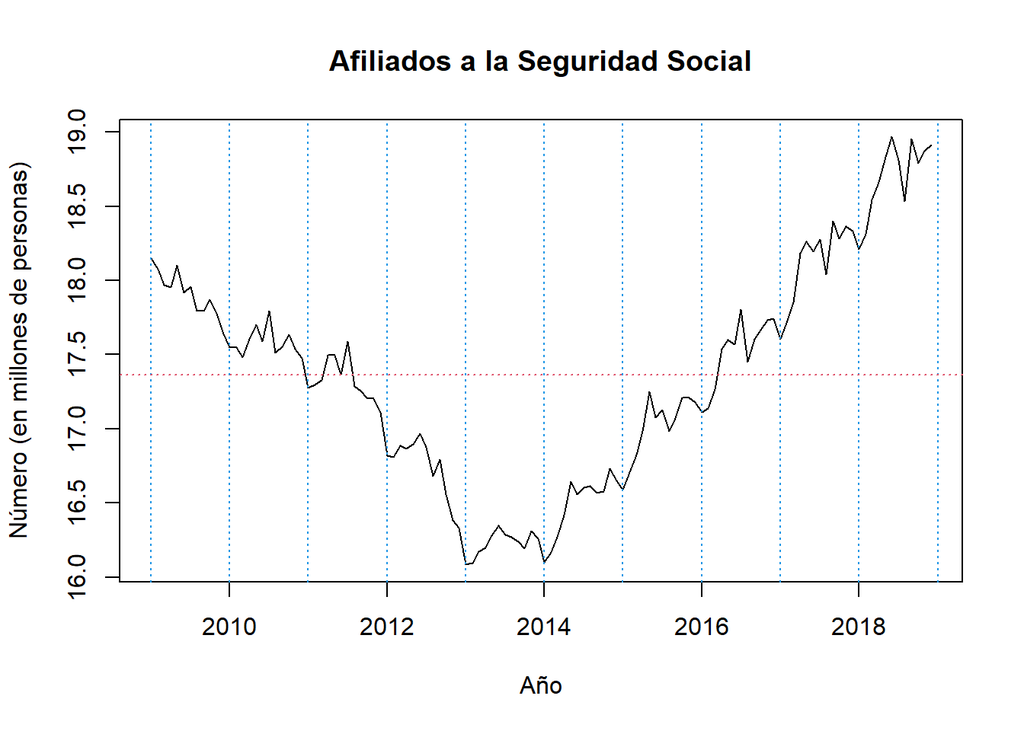

```r
# Plot de la serie
plot(serie, main = "Afiliados a la Seguridad Social", xlab = "Año", ylab = "Número (en millones de personas)")
abline(v = 1990:2020, col = 4, lty = 3)
m <- mean(serie)
abline(h = m, lty = 3, col = 2)
```

**Interpretación:**  
El gráfico indica la evolución mensual del número de afiliados (en millones de personas). Las líneas verticales marcan los años principales, mientras que la línea horizontal roja representa el valor promedio de afiliados. Vemos que tiene tendencia y ciertos picos y valles que se repiten cada año.

# Parte 3: Estadísticas Básicas de la Serie

Se calcula información descriptiva básica como la longitud, el inicio y fin de la serie, y la frecuencia de las observaciones.

```r
# Características de la serie
serie
```

```
##           Jan      Feb      Mar      Apr      May      Jun      Jul      Aug
## 2009 18.15068 18.07578 17.96729 17.95506 18.10017 17.91798 17.95836 17.79640
## 2010 17.54671 17.55041 17.47945 17.60418 17.69957 17.58725 17.79584 17.50944
## 2011 17.27653 17.29863 17.32540 17.49896 17.49725 17.36237 17.59140 17.28708
## 2012 16.81972 16.80979 16.88576 16.86339 16.89380 16.96642 16.87535 16.68242
## 2013 16.08378 16.09464 16.16981 16.19871 16.28198 16.34669 16.28473 16.27145
## 2014 16.10162 16.16848 16.26972 16.42085 16.64336 16.55579 16.60510 16.61112
## 2015 16.58969 16.70537 16.82643 16.98082 17.24826 17.07502 17.12791 16.98330
## 2016 17.11222 17.13667 17.26397 17.53667 17.59889 17.56907 17.80568 17.45245
## 2017 17.60384 17.72891 17.85283 18.18400 18.26190 18.19684 18.27694 18.04019
## 2018 18.21190 18.31447 18.54264 18.65970 18.83294 18.96795 18.81292 18.53542
##           Sep      Oct      Nov      Dec
## 2009 17.79186 17.87066 17.77715 17.64002
## 2010 17.55477 17.63697 17.53961 17.47809
## 2011 17.25538 17.20652 17.20403 17.11179
## 2012 16.79365 16.55798 16.38182 16.33249
## 2013 16.24031 16.19023 16.31159 16.25804
## 2014 16.56585 16.57509 16.73119 16.65188
## 2015 17.07255 17.20904 17.20879 17.18059
## 2016 17.60331 17.66617 17.73411 17.74190
## 2017 18.40014 18.28136 18.36482 18.33111
## 2018 18.95602 18.79272 18.87197 18.91456
```

```r
length(serie)
```

```
## [1] 120
```

```r
start(serie)
```

```
## [1] 2009    1
```

```r
end(serie)
```

```
## [1] 2018   12
```

```r
frequency(serie)
```

```
## [1] 12
```

**Interpretación:**  
Estos datos confirman la estructura temporal de la serie. La frecuencia mensual implica que cada año tiene 12 puntos de observación.

# Parte 4: Análisis Adicional

```r
summary(serie)
```

```
##        V1
##  Min.   :16.08
##  1st Qu.:16.78
##  Median :17.41
##  Mean   :17.36
##  3rd Qu.:17.82
##  Max.   :18.97
```

## 4.1 Varianza

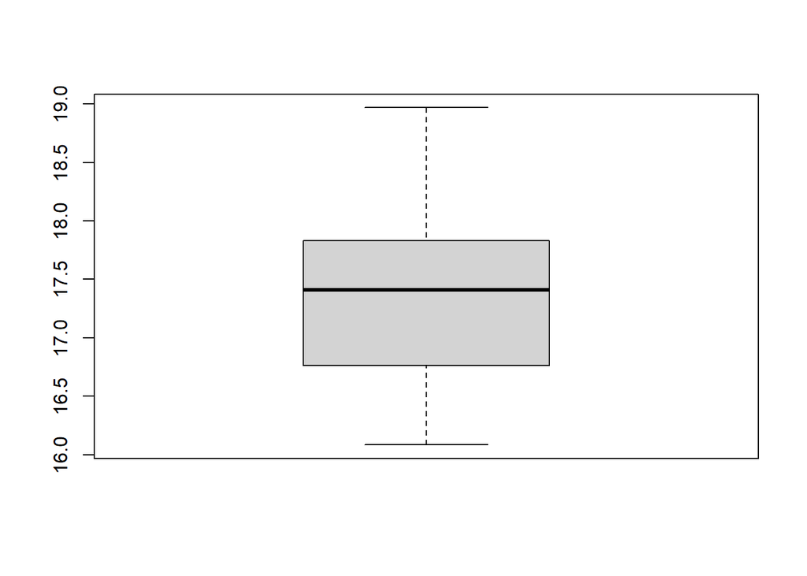

```r
boxplot(serie)
```

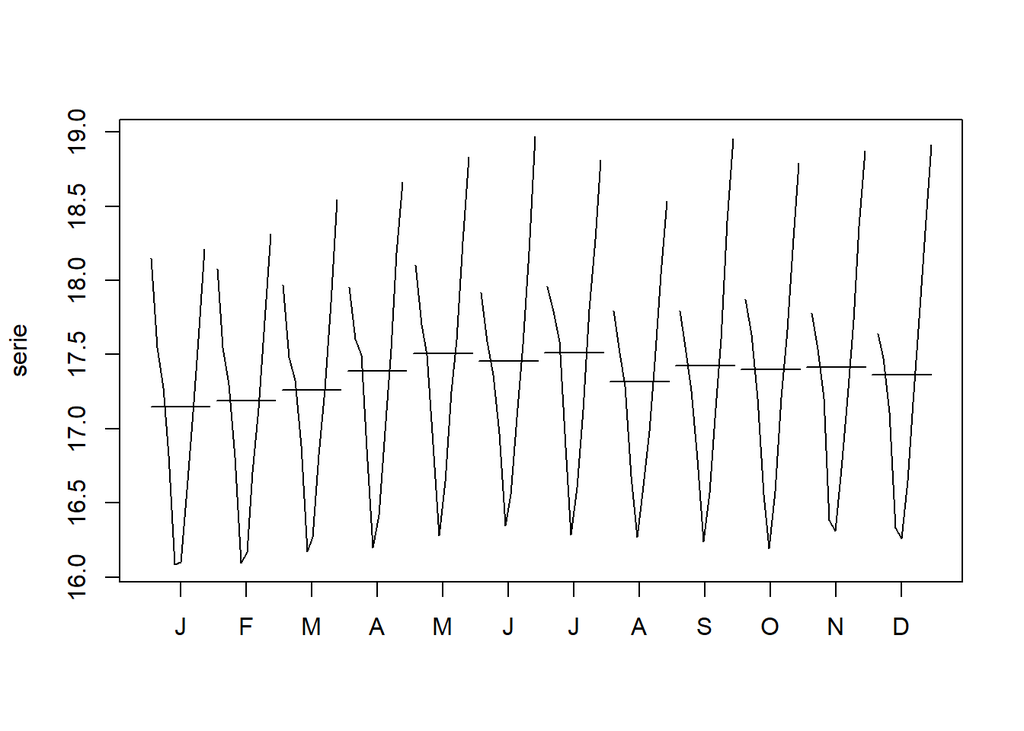

```r
monthplot(serie)
```

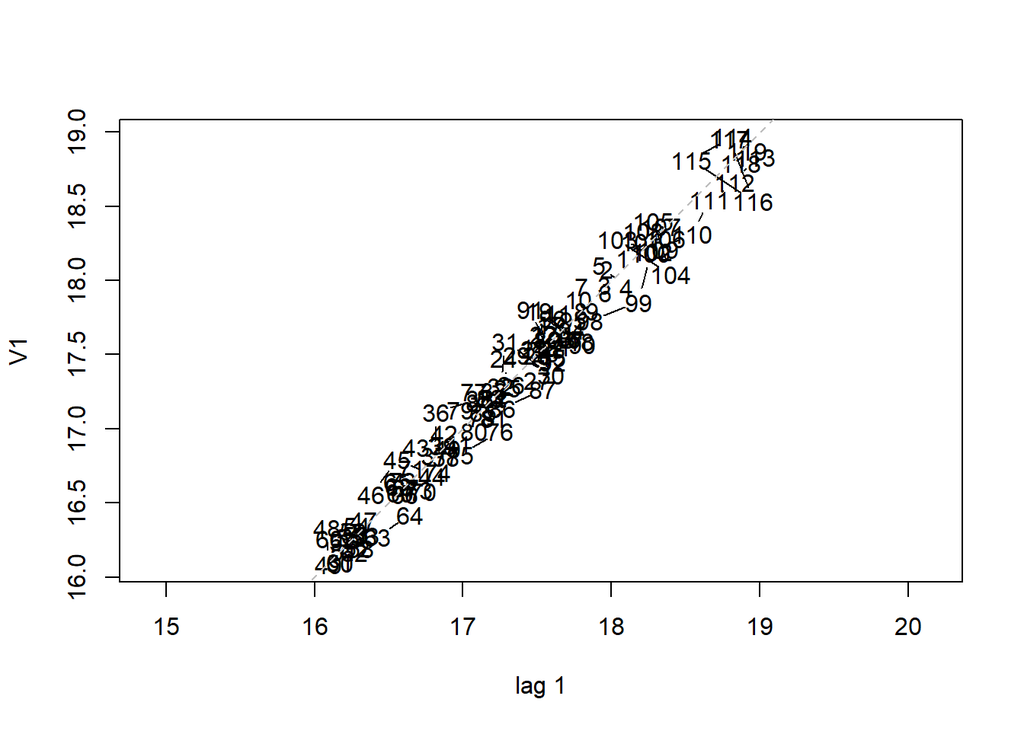

```r
lag.plot(serie)
```

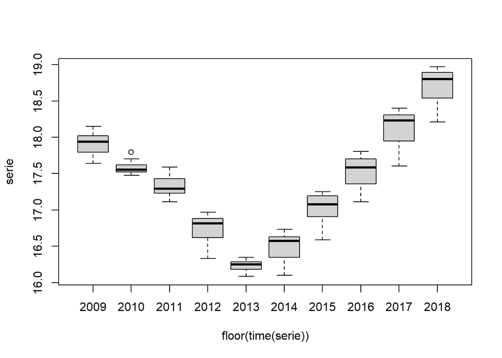

```r
boxplot(serie~floor(time(serie)))
```

## 4.2 Tendencia

Usamos el filtro centrado de rango 2k compensado en los extremos para aproximar la tendencia.

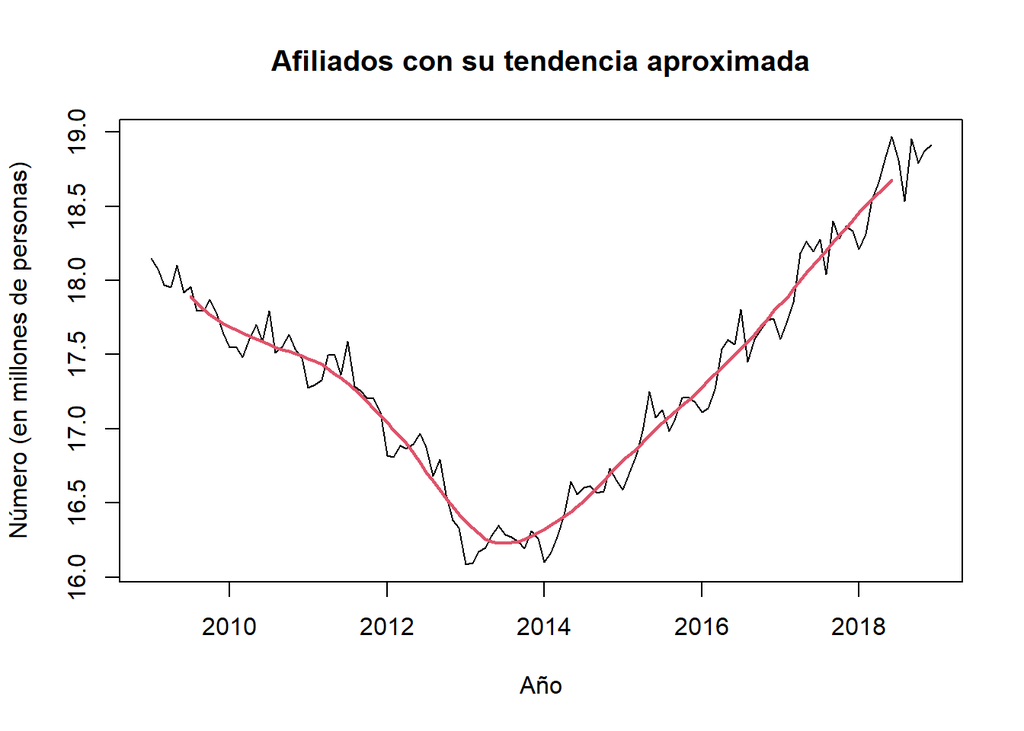

```r
k = 6 #(Orden 2*k=freq)
trend=filter(serie, c(1/(4*k),rep(1/(2*k),2*k-1),1/(4*k)), sides=2)
plot(serie, main = "Afiliados con su tendencia aproximada", xlab = "Año", ylab = "Número (en millones de personas)")
lines(trend, col = 2, lwd = 2)
```

**Observaciones:**  
Al suavizar la serie, vemos que la tendencia es decreciente de 2009-2013 y linealmente creciente de 2014-2018.

## 4.3 Estacionalidad aditiva

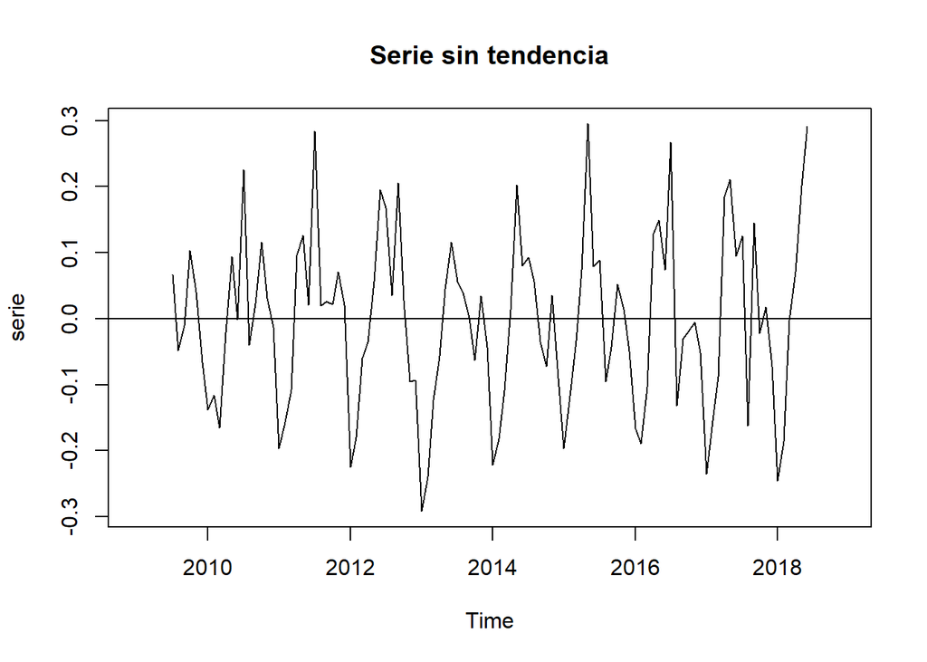

```r
plot(serie-trend, main = "Serie sin tendencia")
abline(h = 0)
```

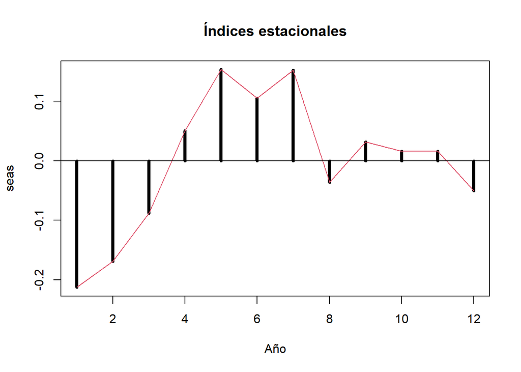

```r
seas = apply(matrix(serie-trend,nrow=2*k), 1, mean, na.rm=T)
plot(seas, type = "h", lwd = 4, main = "Índices estacionales", xlab = "Año")
lines(seas, col = 2)
abline(h = 0)
```

**Observaciones:**  
Los índices estacionales varían entre -0.2 y 0.15 que representaría aproximadamente un 34% del rango intercuartílico y un 12% del rango de la serie.  
Parece haber estacionalidad pero no tenemos muy claro si es aditiva o multiplicativa por culpa de la heterocedastividad entre 2009 y 2013.

## 4.4 Componente de error (o ruido)

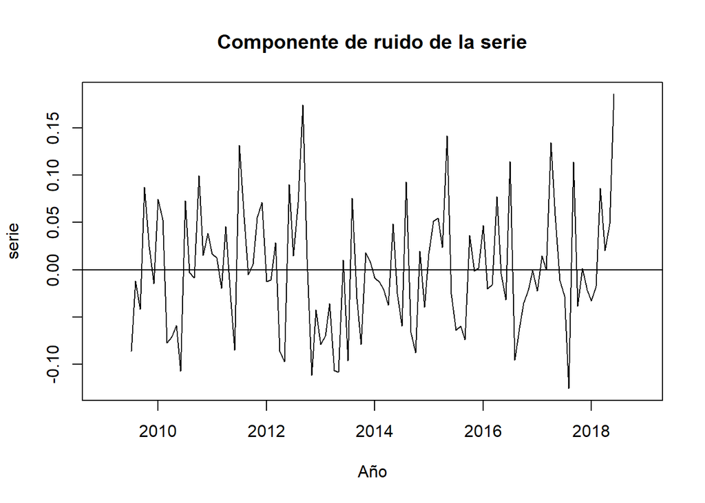

```r
plot(serie-trend-seas, main = "Componente de ruido de la serie", xlab = "Año")
abline(h = 0)
```

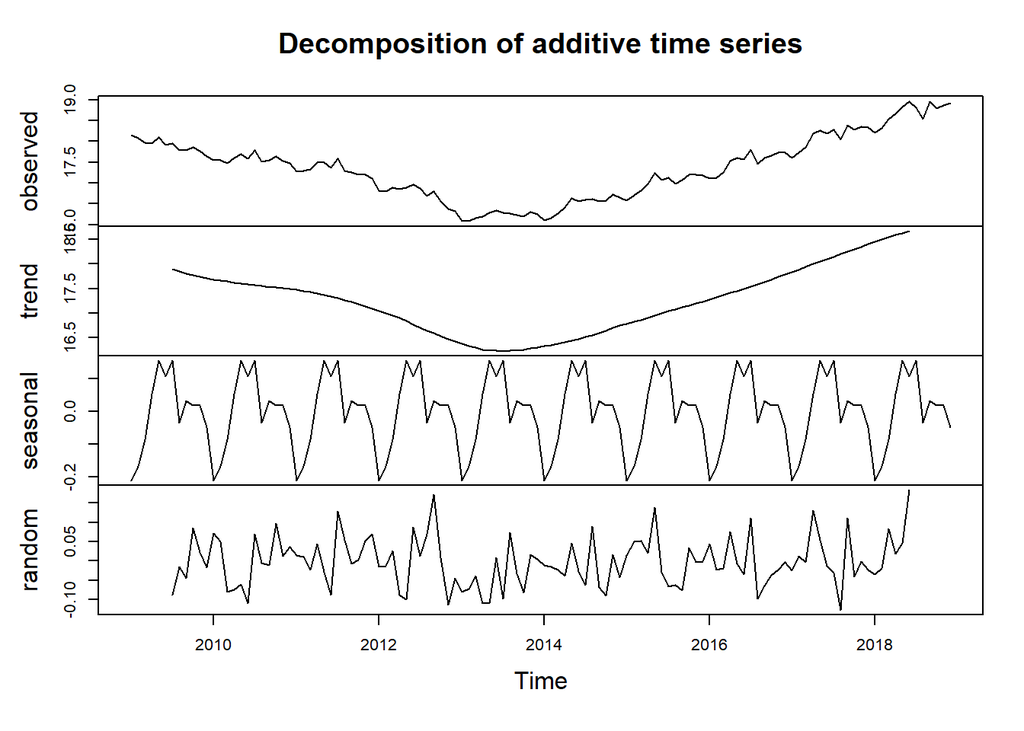

```r
plot(decompose(serie))
```

**Observaciones:**  
Es una serie con error aditivo.  
Tiene tendencia (no constante).  
Tiene estacionalidad aditiva o mutiplicativa (lo veremos con los filtros a aplicar y sus errores).  
Esta serie se clasificaría como una de tipo AAA (tipo 4) o AAM (tipo 6), en siglas ETS.

**Interpretación:**  
Debemos separar la serie en dos trozos:  
-2009 a 2013: su heterocedasticidad y tendencia decreciente son las consecuencias de la crisis económica de 2008, puestos de trabajos inestables que desaparecen  
-2014 a 2018: homocedasticidad y tendencia lineal creciente son indicadores de una recuperación económica positiva y estable.  
Además los picos y valles de los índices estacionales corresponden con las mayores y menores temporadas de contratación.

# Parte 5: Ajustes y predicciones

A continuación para aplicar los filtros supondremos que la serie puede ser o AAN (tipo 2) o AAA (tipo 4) o AAM (tipo 6).  
Definimos las funciones que permitirán calcular los errores de los filtros de ajuste en nuestra serie.

```r
mse2 <- function(par){
  h <- HoltWinters(serie, alpha = par[1], beta = par[2], gamma  = F)
  mean((serie-fitted(h)[,1])^2)
}
rmse2 <- function(par){
  h <- HoltWinters(serie, alpha = par[1], beta = par[2], gamma = F)
  sqrt(mean((serie-fitted(h)[,1])^2))
}
mae2 <- function(par){
  h <- HoltWinters(serie, alpha = par[1], beta = par[2], gamma = F)
  mean(abs(serie-fitted(h)[,1]))
}

mse4 <- function(par){
  h <- HoltWinters(serie, alpha = par[1], beta = par[2], gamma = par[3])
  mean((serie-fitted(h)[,1])^2)
}
rmse4 <- function(par){
  h <- HoltWinters(serie, alpha = par[1], beta = par[2], gamma = par[3])
  sqrt(mean((serie-fitted(h)[,1])^2))
}
mae4 <- function(par){
  h <- HoltWinters(serie, alpha = par[1], beta = par[2], gamma = par[3])
  mean(abs(serie-fitted(h)[,1]))
}

mse6 <- function(par){
  h <- HoltWinters(serie, alpha = par[1], beta = par[2], gamma = par[3], seasonal = "multip")
  mean((serie-fitted(h)[,1])^2)
}
rmse6 <- function(par){
  h <- HoltWinters(serie, alpha = par[1], beta = par[2], gamma = par[3], seasonal = "multip")
  sqrt(mean((serie-fitted(h)[,1])^2))
}
mae6 <- function(par){
  h <- HoltWinters(serie, alpha = par[1], beta = par[2], gamma = par[3], seasonal = "multip")
  mean(abs(serie-fitted(h)[,1]))
}
```

## 5.1 Suponiendo que es AAN (a mano)

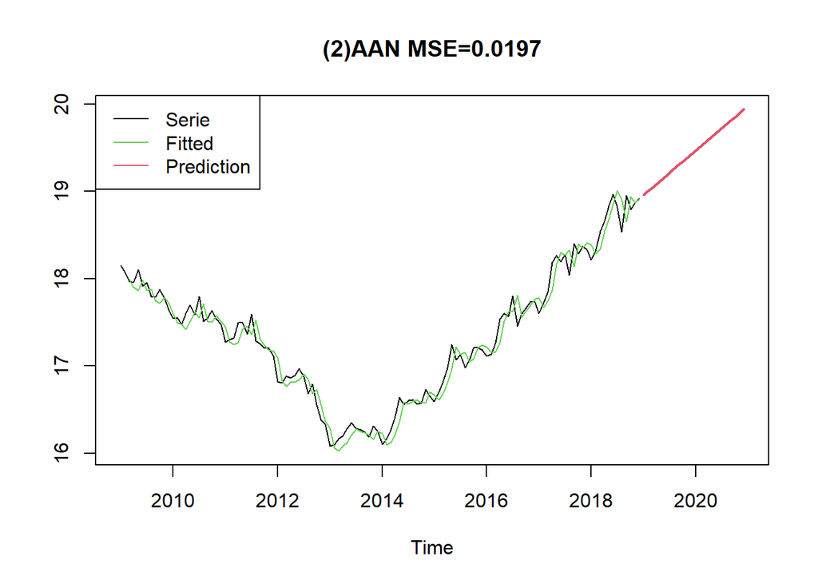

```r
par = c(0.5,0.5)
sol <- optim(par, mse2, method = "L-BFGS-B", lower = c(1e-4,1e-4), upper = c(0.9999,0.9999))
hw21 <- HoltWinters(serie, alpha = sol$par[1], beta = sol$par[2], gamma = F)
phw21 <- predict(hw21,24)
ts.plot(serie, phw21, hw21$fitted[,1], col = c(1,2,3), lwd = c(1,2), main = paste0("(2)AAN MSE=", round(sol$value,4)))
legend("topleft", legend = c("Serie", "Fitted", "Prediction"), col = c(1,3,2), lty = 1, bty = "y")
```

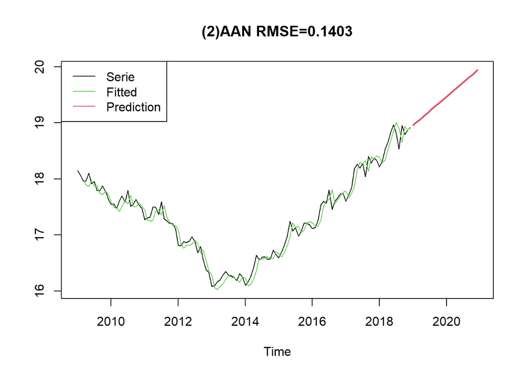

```r
sol <- optim(par, rmse2, method = "L-BFGS-B", lower = c(1e-4,1e-4), upper = c(0.9999,0.9999))
hw22 <- HoltWinters(serie, alpha = sol$par[1], beta = sol$par[2], gamma = F)
phw22 <- predict(hw22,24)
ts.plot(serie, phw22, hw22$fitted[,1], col = c(1,2,3), lwd = c(1,2), main = paste0("(2)AAN RMSE=", round(sol$value,4)))
legend("topleft", legend = c("Serie", "Fitted", "Prediction"), col = c(1,3,2), lty = 1, bty = "y")
```

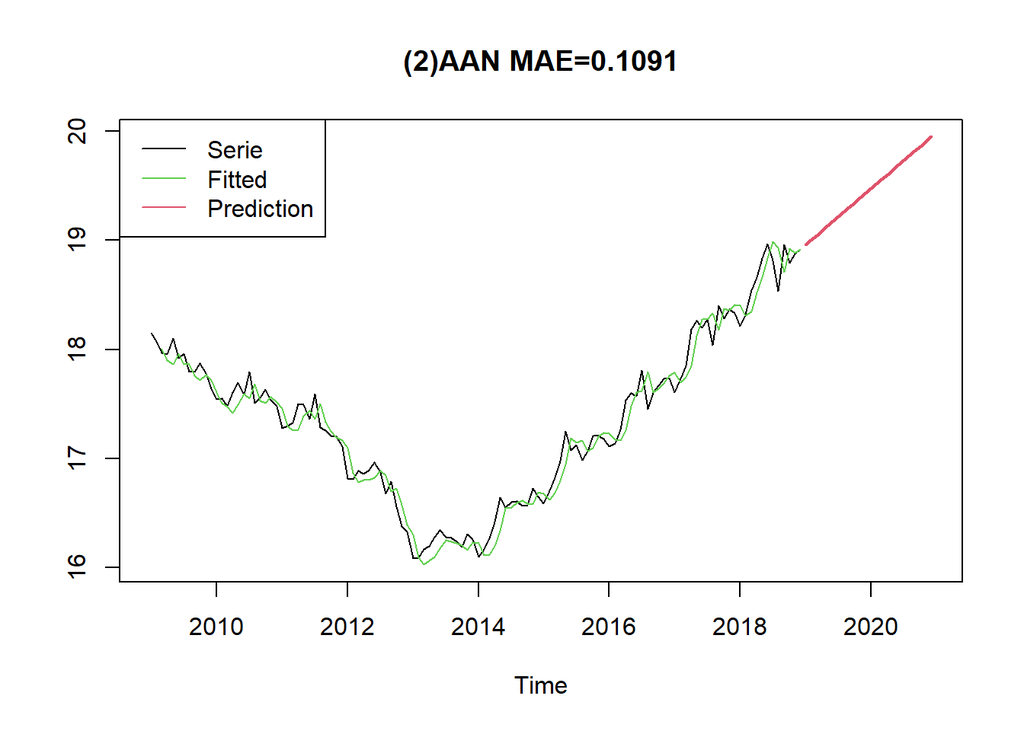

```r
sol <- optim(par, mae2, method = "L-BFGS-B", lower = c(1e-4,1e-4), upper = c(0.9999,0.9999))
hw23 <- HoltWinters(serie, alpha = sol$par[1], beta = sol$par[2], gamma = F)
phw23 <- predict(hw23,24)
ts.plot(serie, phw23, hw23$fitted[,1], col = c(1,2,3), lwd = c(1,2), main = paste0("(2)AAN MAE=", round(sol$value,4)))
legend("topleft", legend = c("Serie", "Fitted", "Prediction"), col = c(1,3,2), lty = 1, bty = "y")
```

## 5.2 Suponiendo que es AAA (a mano)

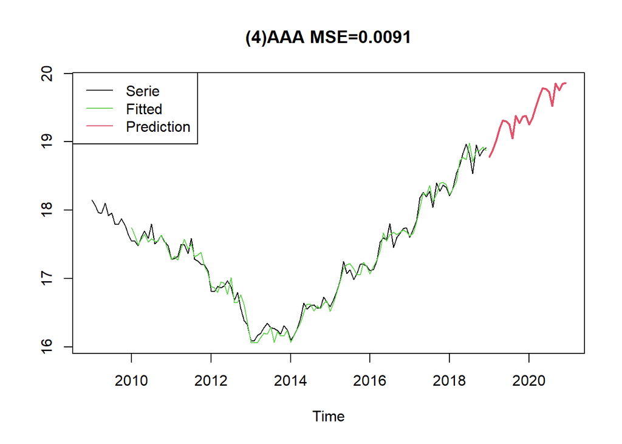

```r
par = c(0.5,0.5,0.5)
sol <- optim(par, mse4, method = "L-BFGS-B", lower = c(1e-4,1e-4,1e-4), upper = c(0.9999,0.9999,0.9999))
hw41 <- HoltWinters(serie, alpha = sol$par[1], beta = sol$par[2], gamma = sol$par[3])
phw41 <- predict(hw41,24)
ts.plot(serie, phw41, hw41$fitted[,1], col = c(1,2,3), lwd = c(1,2), main = paste0("(4)AAA MSE=", round(sol$value,4)))
legend("topleft", legend = c("Serie", "Fitted", "Prediction"), col = c(1,3,2), lty = 1, bty = "y")
```

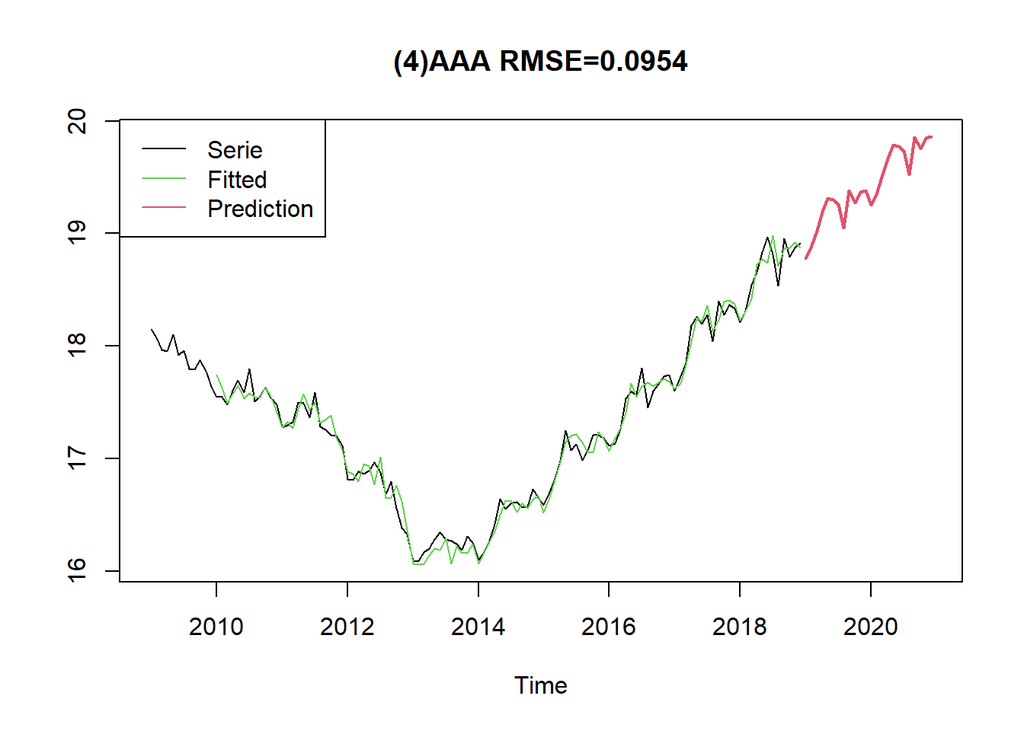

```r
sol <- optim(par, rmse4, method = "L-BFGS-B", lower = c(1e-4,1e-4,1e-4), upper = c(0.9999,0.9999,0.9999))
hw42 <- HoltWinters(serie, alpha = sol$par[1], beta = sol$par[2], gamma = sol$par[3])
phw42 <- predict(hw42,24)
ts.plot(serie, phw42, hw42$fitted[,1], col = c(1,2,3), lwd = c(1,2), main = paste0("(4)AAA RMSE=", round(sol$value,4)))
legend("topleft", legend = c("Serie", "Fitted", "Prediction"), col = c(1,3,2), lty = 1, bty = "y")
```

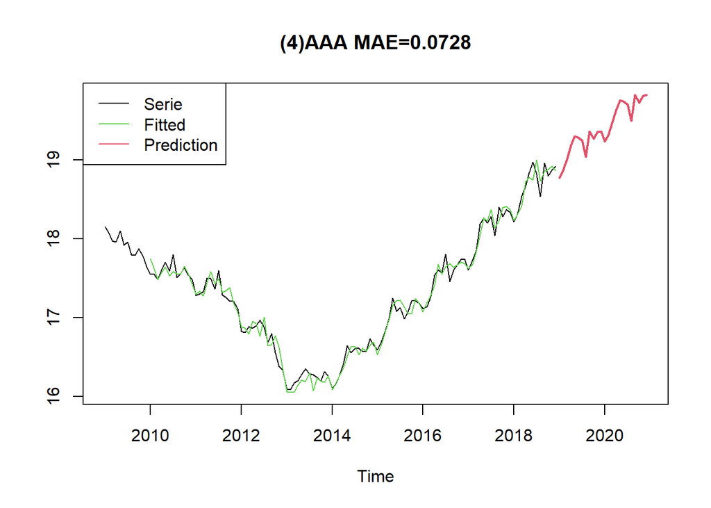

```r
sol <- optim(par, mae4, method = "L-BFGS-B", lower = c(1e-4,1e-4,1e-4), upper = c(0.9999,0.9999,0.9999))
hw43 <- HoltWinters(serie, alpha = sol$par[1], beta = sol$par[2], gamma = sol$par[3])
phw43 <- predict(hw43,24)
ts.plot(serie, phw43, hw43$fitted[,1], col = c(1,2,3), lwd = c(1,2), main = paste0("(4)AAA MAE=", round(sol$value,4)))
legend("topleft", legend = c("Serie", "Fitted", "Prediction"), col = c(1,3,2), lty = 1, bty = "y")
```

## 5.3 Suponiendo que es AAM (a mano)

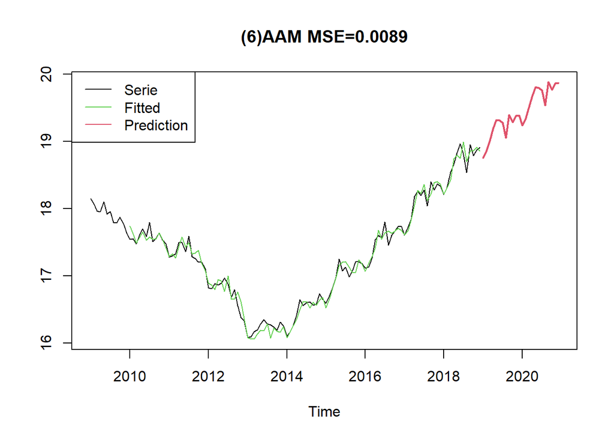

```r
par = c(0.5,0.5,0.5)
sol <- optim(par, mse6, method = "L-BFGS-B", lower = c(1e-4,1e-4,1e-4), upper = c(0.9999,0.9999,0.9999))
hw61 <- HoltWinters(serie, alpha = sol$par[1], beta = sol$par[2], gamma = sol$par[3], seasonal = "m")
phw61 <- predict(hw61,24)
ts.plot(serie, phw61, hw61$fitted[,1], col = c(1,2,3), lwd = c(1,2), main = paste0("(6)AAM MSE=", round(sol$value,4)))
legend("topleft", legend = c("Serie", "Fitted", "Prediction"), col = c(1,3,2), lty = 1, bty = "y")
```

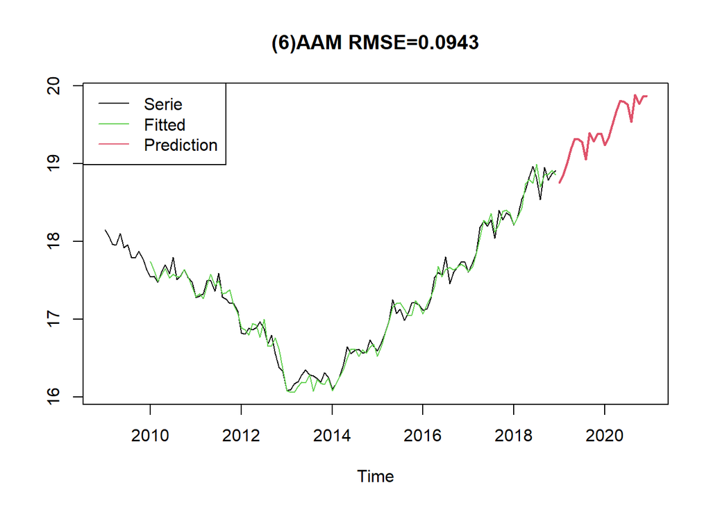

```r
sol <- optim(par, rmse6, method = "L-BFGS-B", lower = c(1e-4,1e-4,1e-4), upper = c(0.9999,0.9999,0.9999))
hw62 <- HoltWinters(serie, alpha = sol$par[1], beta = sol$par[2], gamma = sol$par[3], seasonal = "m")
phw62 <- predict(hw62,24)
ts.plot(serie, phw62, hw62$fitted[,1], col = c(1,2,3), lwd = c(1,2), main = paste0("(6)AAM RMSE=", round(sol$value,4)))
legend("topleft", legend = c("Serie", "Fitted", "Prediction"), col = c(1,3,2), lty = 1,  bty = "y")
```

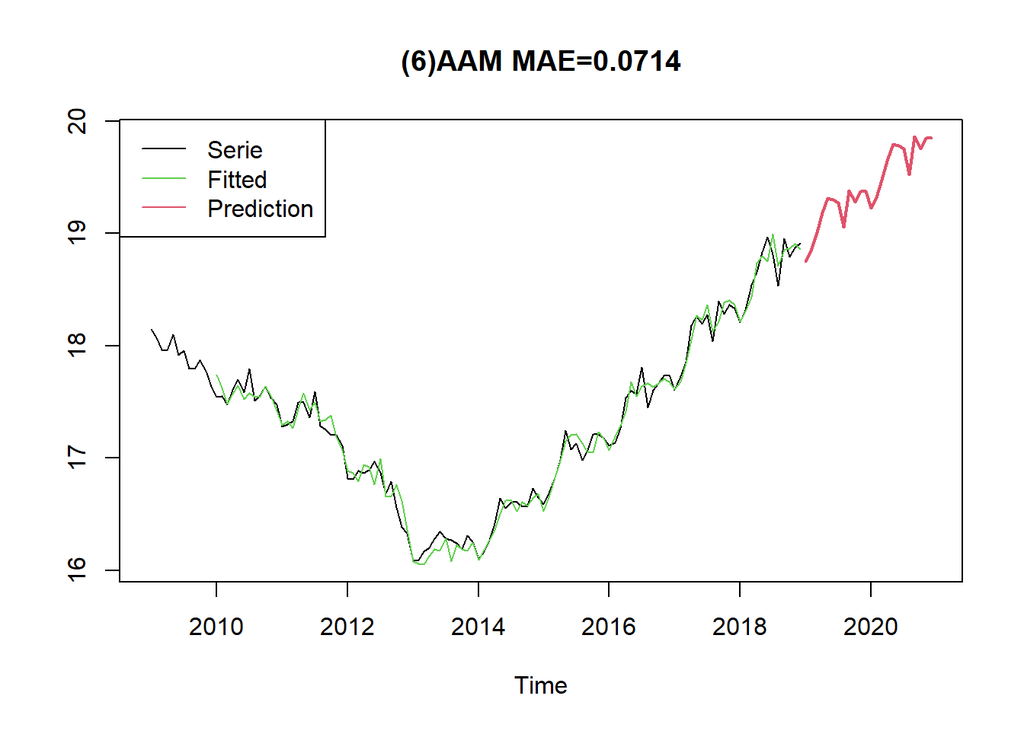

```r
sol <- optim(par, mae6, method = "L-BFGS-B", lower = c(1e-4,1e-4,1e-4), upper = c(0.9999,0.9999,0.9999))
hw63 <- HoltWinters(serie, alpha = sol$par[1], beta = sol$par[2], gamma = sol$par[3],seasonal = "m")
phw63 <- predict(hw63,24)
ts.plot(serie, phw63, hw63$fitted[,1], col = c(1,2,3), lwd = c(1,2), main = paste0("(6)AAM MAE=", round(sol$value,4)))
legend("topleft", legend = c("Serie", "Fitted", "Prediction"), col = c(1,3,2), lty = 1, bty = "y")
```

## 5.4 Procedimientos automatizados con las predicciones

```r
(h2 <- HoltWinters(serie, alpha = NULL, beta = NULL, gamma = FALSE, seasonal = "additive"))
```

```
## Holt-Winters exponential smoothing with trend and without seasonal component.
##
## Call:
## HoltWinters(x = serie, alpha = NULL, beta = NULL, gamma = FALSE,     seasonal = "additive")
##
## Smoothing parameters:
##  alpha: 0.7775293
##  beta : 0.06388178
##  gamma: FALSE
##
## Coefficients:
##          [,1]
## a 18.91435256
## b  0.04268559
```

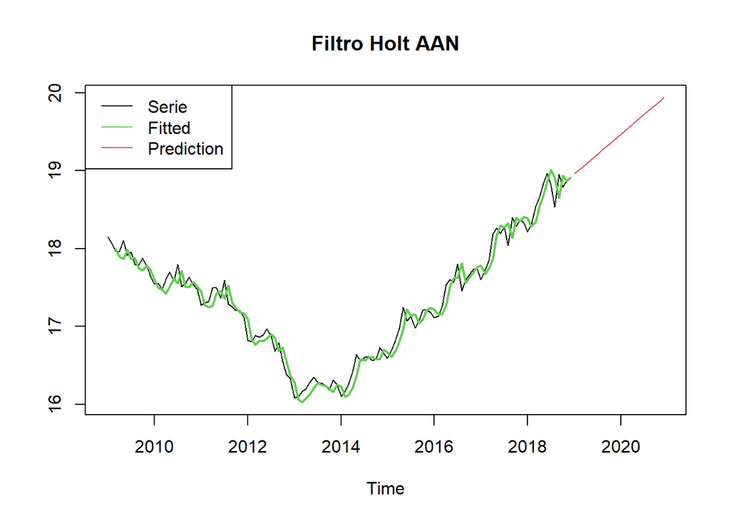

```r
pred2=predict(h2,24)
ts.plot(serie,fitted(h2)[,1],pred2,col=c(1,3,2),lwd=c(1,2), main = "Filtro Holt AAN")
legend("topleft", legend = c("Serie", "Fitted", "Prediction"), col = c(1,3,2), lty = 1, bty = "y")
```

```r
(h4 <- HoltWinters(serie, alpha = NULL, beta = NULL, gamma = NULL, seasonal = "additive"))
```

```
## Holt-Winters exponential smoothing with trend and additive seasonal component.
##
## Call:
## HoltWinters(x = serie, alpha = NULL, beta = NULL, gamma = NULL,     seasonal = "additive")
##
## Smoothing parameters:
##  alpha: 0.4601209
##  beta : 0.2101626
##  gamma: 0.6908528
##
## Coefficients:
##             [,1]
## a   18.904102220
## b    0.039697683
## s1  -0.166745510
## s2  -0.111463701
## s3   0.003303300
## s4   0.130084805
## s5   0.208778324
## s6   0.158667402
## s7   0.076384077
## s8  -0.174184466
## s9   0.120128718
## s10 -0.024053231
## s11  0.031002570
## s12  0.003350691
```

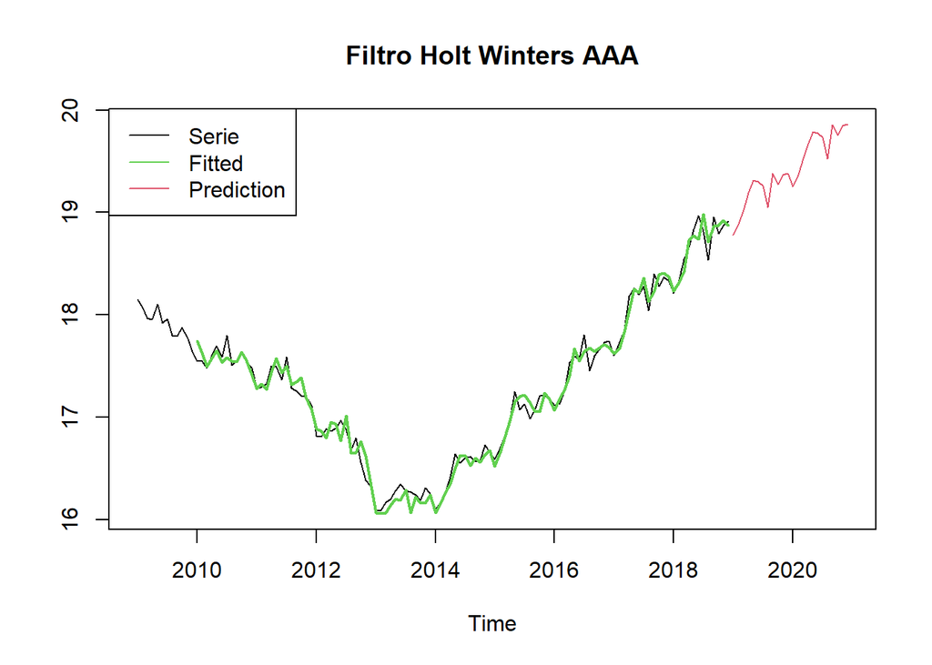

```r
pred4 = predict(h4,24)
ts.plot(serie, fitted(h4)[,1], pred4, col = c(1,3,2), lwd = c(1,2), main = "Filtro Holt Winters AAA")
legend("topleft", legend = c("Serie", "Fitted", "Prediction"), col = c(1,3,2), lty = 1, bty = "y")
```

```r
(h6 <- HoltWinters(serie, alpha = NULL, beta = NULL, gamma = NULL, seasonal = "multiplicative"))
```

```
## Holt-Winters exponential smoothing with trend and multiplicative seasonal component.
##
## Call:
## HoltWinters(x = serie, alpha = NULL, beta = NULL, gamma = NULL,     seasonal = "multiplicative")
##
## Smoothing parameters:
##  alpha: 0.459852
##  beta : 0.2211541
##  gamma: 0.6695764
##
## Coefficients:
##            [,1]
## a   18.90088998
## b    0.04027791
## s1   0.99030386
## s2   0.99316396
## s3   0.99945814
## s4   1.00682888
## s5   1.01153584
## s6   1.00887741
## s7   1.00500737
## s8   0.99137794
## s9   1.00689302
## s10  0.99921164
## s11  1.00201231
## s12  1.00021340
```

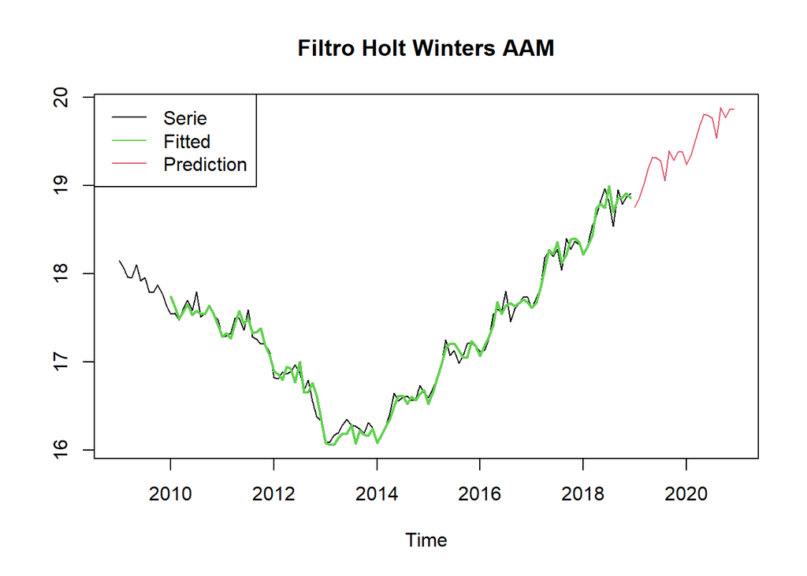

```r
pred6 = predict(h6,24)
ts.plot(serie, fitted(h6)[,1], pred6, col = c(1,3,2), lwd = c(1,2), main = "Filtro Holt Winters AAM")
legend("topleft", legend = c("Serie", "Fitted", "Prediction"), col = c(1,3,2), lty = 1, bty = "y")
```

```r
summary(pred2-pred4)
```

```
##      pred2
##  Min.   :-0.18359
##  1st Qu.:-0.07477
##  Median : 0.02933
##  Mean   : 0.02633
##  3rd Qu.: 0.10695
##  Max.   : 0.24419
```

```r
summary(pred2-pred6)
```

```
##      pred2
##  Min.   :-0.19486
##  1st Qu.:-0.08553
##  Median : 0.02997
##  Mean   : 0.01928
##  3rd Qu.: 0.09853
##  Max.   : 0.23311
```

```r
summary(pred4-pred6)
```

```
##      pred4
##  Min.   :-0.029904
##  1st Qu.:-0.018262
##  Median :-0.011348
##  Mean   :-0.007043
##  3rd Qu.: 0.002698
##  Max.   : 0.020346
```

**Interpretación:**  
Nuestra suposición de presencia de estacionalidad ha sido confirmada.  
Observando los diferentes errores claramente debemos aplicar o bien el Holt-Winters de tipo 4 o 6.  
Como la varianza no es constante en toda la serie y para ambos filtros debemos estimar el mismo número de parámetros nos quedaremos con el filtro de Holt-Winters para las series con estacionalidad multiplicativa.

```r
filtro <- h6
prediction <- pred6
```

# Parte 6: Partición de la serie temporal en etapas

Como hemos visto anteriormente que hay homocedasticidad en los últimos cinco años decidimos realizar un estudio de la serie partida en dos etapas: de 2009-2013 y de 2014-2018.  
Queremos ver cómo afectaría a las predicciones y a la clasificación de las sub-series.

```r
serie1 <- window(data, start = 2009, end = c(2013, 12))
serie2 <- window(data, start = 2014, end = c(2018, 12))
```

## 6.1 Descriptivas

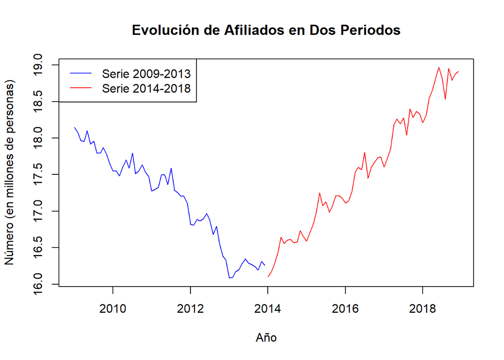

```r
x_range <- range(time(serie1), time(serie2))
y_range <- range(c(serie1, serie2), na.rm=TRUE)

plot(serie1, type = "l", col = "blue", xlab = "Año", ylab = "Número (en millones de personas)", main = "Evolución de Afiliados en Dos Periodos", xlim = x_range, ylim = y_range)
lines(serie2, col = "red")
legend("topleft", legend = c("Serie 2009-2013","Serie 2014-2018"), col = c("blue", "red"), lty = 1)
```

```r
serie1
```

```
##           Jan      Feb      Mar      Apr      May      Jun      Jul      Aug
## 2009 18.15068 18.07578 17.96729 17.95506 18.10017 17.91798 17.95836 17.79640
## 2010 17.54671 17.55041 17.47945 17.60418 17.69957 17.58725 17.79584 17.50944
## 2011 17.27653 17.29863 17.32540 17.49896 17.49725 17.36237 17.59140 17.28708
## 2012 16.81972 16.80979 16.88576 16.86339 16.89380 16.96642 16.87535 16.68242
## 2013 16.08378 16.09464 16.16981 16.19871 16.28198 16.34669 16.28473 16.27145
##           Sep      Oct      Nov      Dec
## 2009 17.79186 17.87066 17.77715 17.64002
## 2010 17.55477 17.63697 17.53961 17.47809
## 2011 17.25538 17.20652 17.20403 17.11179
## 2012 16.79365 16.55798 16.38182 16.33249
## 2013 16.24031 16.19023 16.31159 16.25804
```

```r
length(serie1)
```

```
## [1] 60
```

```r
start(serie1)
```

```
## [1] 2009    1
```

```r
end(serie1)
```

```
## [1] 2013   12
```

```r
frequency(serie1)
```

```
## [1] 12
```

```r
summary(serie1)
```

```
##        V1
##  Min.   :16.08
##  1st Qu.:16.65
##  Median :17.29
##  Mean   :17.16
##  3rd Qu.:17.61
##  Max.   :18.15
```

```r
serie2
```

```
##           Jan      Feb      Mar      Apr      May      Jun      Jul      Aug
## 2014 16.10162 16.16848 16.26972 16.42085 16.64336 16.55579 16.60510 16.61112
## 2015 16.58969 16.70537 16.82643 16.98082 17.24826 17.07502 17.12791 16.98330
## 2016 17.11222 17.13667 17.26397 17.53667 17.59889 17.56907 17.80568 17.45245
## 2017 17.60384 17.72891 17.85283 18.18400 18.26190 18.19684 18.27694 18.04019
## 2018 18.21190 18.31447 18.54264 18.65970 18.83294 18.96795 18.81292 18.53542
##           Sep      Oct      Nov      Dec
## 2014 16.56585 16.57509 16.73119 16.65188
## 2015 17.07255 17.20904 17.20879 17.18059
## 2016 17.60331 17.66617 17.73411 17.74190
## 2017 18.40014 18.28136 18.36482 18.33111
## 2018 18.95602 18.79272 18.87197 18.91456
```

```r
length(serie2)
```

```
## [1] 60
```

```r
start(serie2)
```

```
## [1] 2014    1
```

```r
end(serie2)
```

```
## [1] 2018   12
```

```r
frequency(serie2)
```

```
## [1] 12
```

```r
summary(serie2)
```

```
##        V1
##  Min.   :16.10
##  1st Qu.:16.94
##  Median :17.58
##  Mean   :17.57
##  3rd Qu.:18.28
##  Max.   :18.97
```

## 6.2 Clasificación serie1

Procedemos de la misma manera como con la serie total.

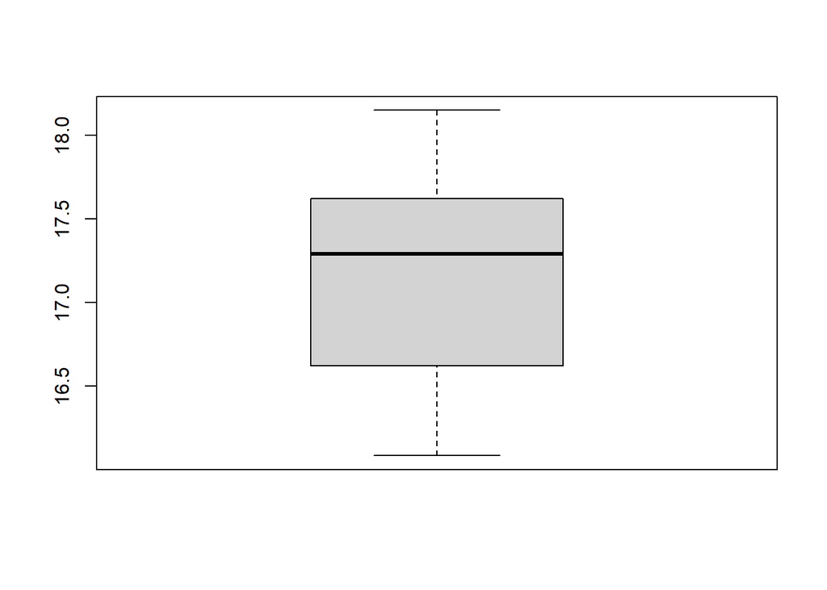

```r
boxplot(serie1)
```

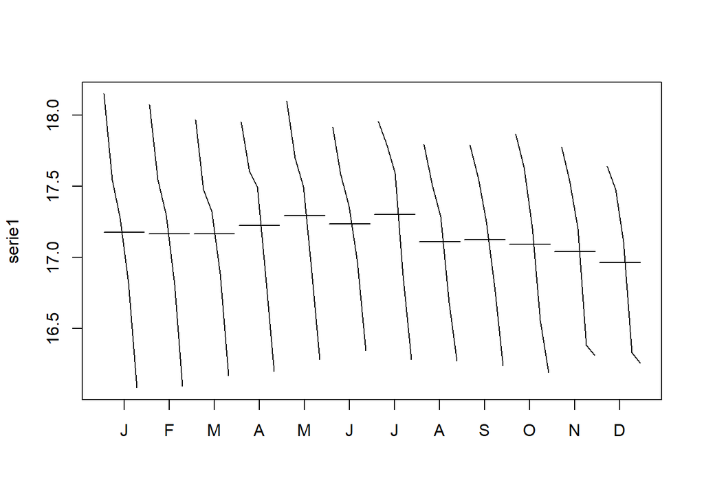

```r
monthplot(serie1)
```

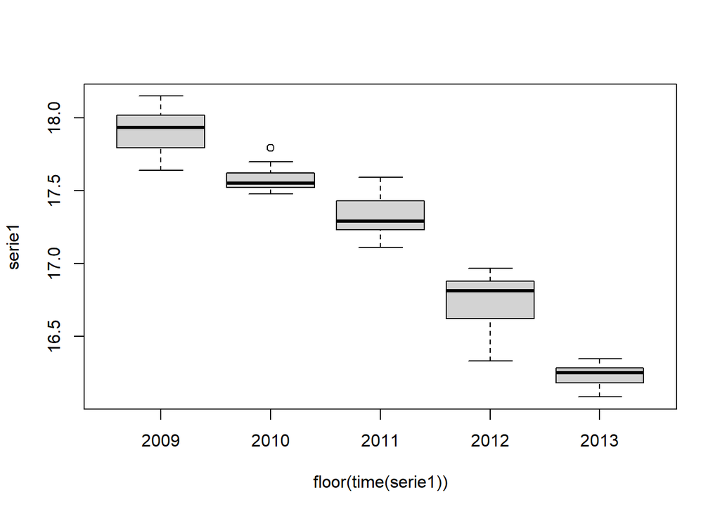

```r
boxplot(serie1~floor(time(serie1)))
```

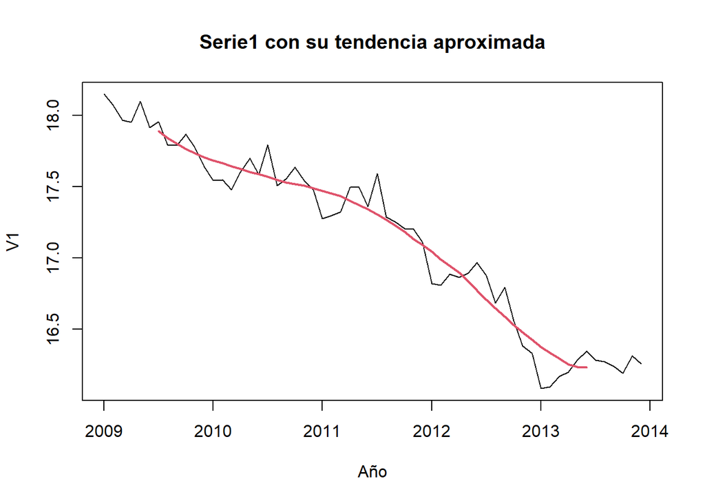

```r
k = 6 #(Orden 2*k=freq)
trend1 = filter(serie1, c(1/(4*k),rep(1/(2*k),2*k-1),1/(4*k)), sides = 2)
plot(serie1, main = "Serie1 con su tendencia aproximada", xlab = "Año")
lines(trend1, col = 2, lwd = 2)
```

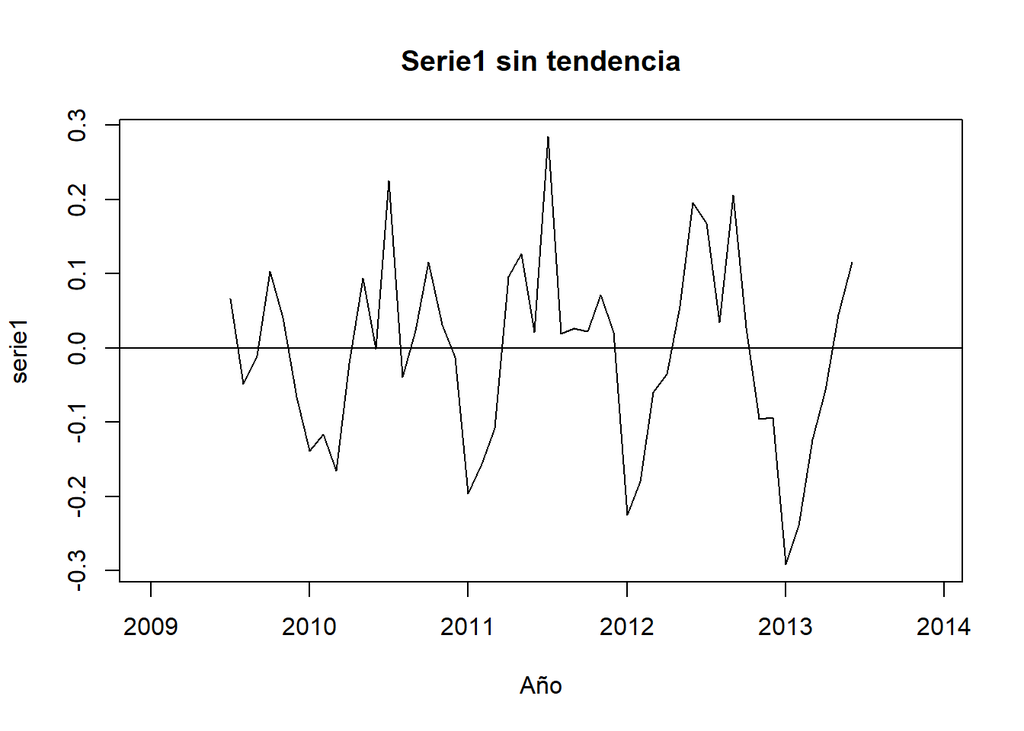

```r
plot(serie1-trend1, main = "Serie1 sin tendencia", xlab = "Año")
abline(h = 0)
```

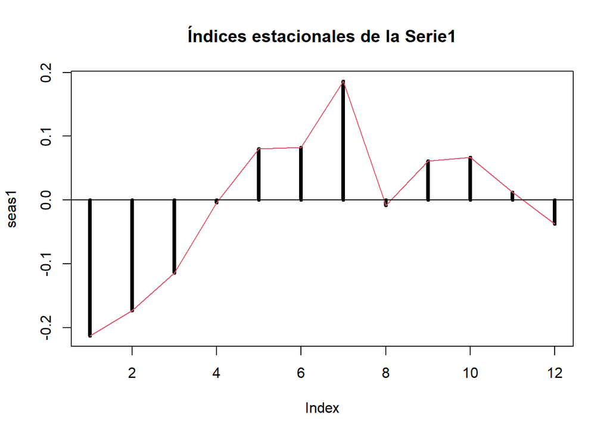

```r
seas1 = apply(matrix(serie1-trend1,nrow=2*k), 1, mean, na.rm=T)
plot(seas1, type = "h", lwd = 4, main="Índices estacionales de la Serie1")
lines(seas1, col = 2)
abline(h = 0)
```

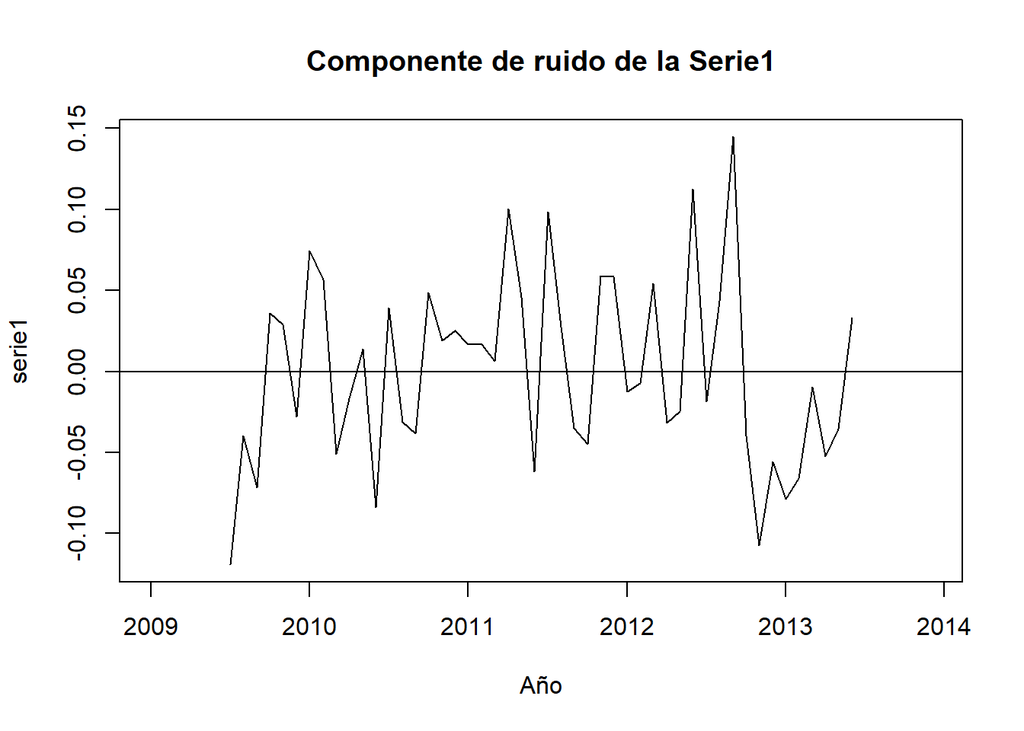

```r
plot(serie1-trend1-seas1, main = "Componente de ruido de la Serie1", xlab = "Año")
abline(h = 0)
```

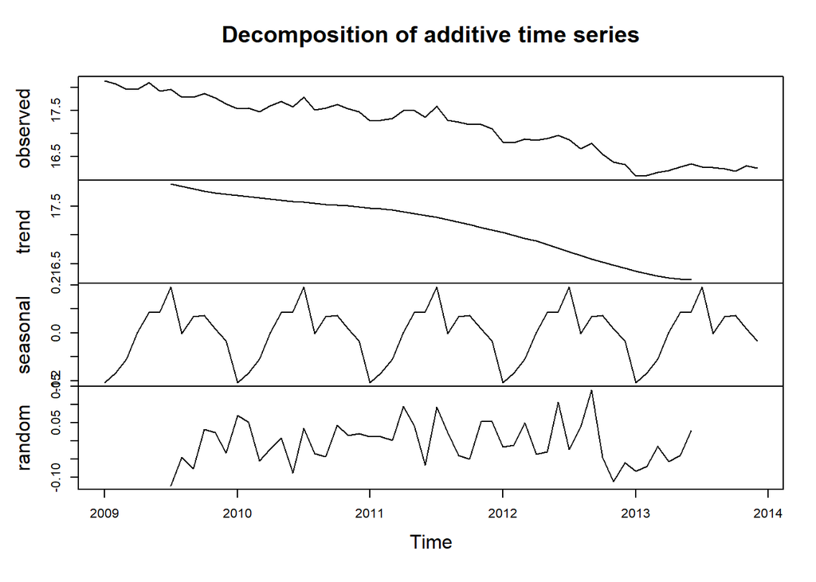

```r
plot(decompose(serie1))
```

**Observaciones:**  
Hay tendencia decreciente y estacionalidad multiplicativa por la heterocedasticidad.  
Es una serie de tipo 6: AAM.

**Interpretación:**  
Debido a la crisis económica de 2008, el número de afiliados fue decreciendo en España hasta 2013.  
La serie1 representa las consecuencias recesivas de esta crisis.  
Hacia finales de 2013-2014 se comienzan a observar inicios de recuperación económica.